# Estimating time windows of divergence

Samuel Forbes, Jacob Dink & Brock Ferguson

2025-06-17

> **Our Experiment**: Each eyetrackingR vignette uses the *eyetrackingR* package to analyze real data from a simple 2-alternative forced choice (2AFC) word recognition task administered to 19- and 24-month-olds. On each trial, infants were shown a picture of an animate object (e.g., a horse) and an inanimate object (e.g., a spoon). After inspecting the images, they disappeared and they heard a label referring to one of them (e.g., “The horse is nearby!”). Finally, the objects re-appeared on the screen and they were prompted to look at the target (e.g., “Look at the horse!”).

## Overview of this vignette

In this vignette, we want to ascertain when a predictor had a significant effect during a trial. Analyses that aggregate over the trial window tell us *whether* an effect was significant, growth curve analyses tell us the trajectory of our effect over the course of the trial, and onset-contingent analyses can tell you reaction times for certain experimental designs. But none of these approaches allow you to ask: What is the onset of some predictor’s effect, and how long does the effect last? eyetrackingR includes two types of analyses for answering these questions, both of which we cover here.

## Prerequisites

Before performing this analysis, we’ll need to prepare and clean our dataset. Here we will to do this quickly and with few notes but, for more information, see the vignette on preparing your data.

```r
set.seed(42)

library("Matrix")
library("lme4")
library("ggplot2")
library("eyetrackingR")
data("word_recognition")
data <- make_eyetrackingr_data(word_recognition,
                       participant_column = "ParticipantName",
                       trial_column = "Trial",
                       time_column = "TimeFromTrialOnset",
                       trackloss_column = "TrackLoss",
                       aoi_columns = c('Animate','Inanimate'),
                       treat_non_aoi_looks_as_missing = TRUE
                )

# subset to response window post word-onset
response_window <- subset_by_window(data,
                                    window_start_time = 15500,
                                    window_end_time = 21000,
                                    rezero = FALSE)
```

```
## Avg. window length in new data will be 5500
```

```r
# analyze amount of trackloss by subjects and trials
(trackloss <- trackloss_analysis(data = response_window))

# remove trials with > 25% of trackloss
response_window_clean <- clean_by_trackloss(data = response_window,
                                            trial_prop_thresh = .25)
```

```
## Performing Trackloss Analysis...
```

```
## Will exclude trials whose trackloss proportion is greater than : 0.25
```

```
##  ...removed  33  trials.
```

```r
# create Target condition column
response_window_clean$Target <- as.factor( ifelse(test = grepl('(Spoon|Bottle)', response_window_clean$Trial),
                                       yes = 'Inanimate',
                                       no  = 'Animate') )
```

To begin, we need to use `make_time_sequence_data` to generate a time-binned dataframe. We’ll summarize by subjects for now.

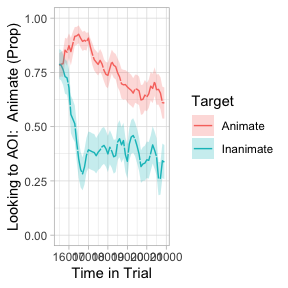

```r
response_time <- make_time_sequence_data(response_window_clean,
                                  time_bin_size = 100,
                                  predictor_columns = c("Target"),
                                  aois = "Animate",
                                  summarize_by = "ParticipantName" )

# visualize timecourse
plot(response_time, predictor_column = "Target") +
  theme_light() +
  coord_cartesian(ylim = c(0,1))
```

## Testing Time-Bins Independently

One straightforward method of testing for divergences is simply to perform a statistical test on each time-bin separately. This method is problematic, but walking through it and explaining why will help set up other methods.

EyetrackingR provides `analyze_time_bins`, a function that makes sequential tests like this easy to implement.

```r
tb_analysis <- analyze_time_bins(data = response_time, predictor_column = "Target", test = "t.test", alpha = .05)
```

```
## Computing t.test for each time bin...
```

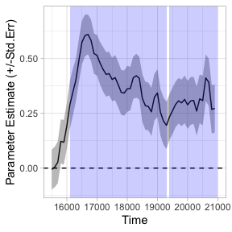

```r
plot(tb_analysis, type = "estimate") + theme_light()
```

```r
summary(tb_analysis)
```

```
## Test Type:    t.test
## Predictor:    Target
## Formula:  Prop ~ Target
## Runs of Significant Time Bins:
## Positive Run 1  =====
##  Time:        16100 - 19300
## Positive Run 2  =====
##  Time:        19400 - 21000
```

This method suggests that looking diverges across conditions as early as 16100. However, this method does not control the family-wise error rate–that is, the probability of finding at least one divergence across conditions where none actually exists. Because we are performing so many tests, we are bound to get *some* statistically significant results, even if no effect is actually present. If there is no real effect, if each test is completely independent, and if our alpha for each test is .05, then the odds of at least one false alarm is…

```r
alpha <- .05
num_time_bins <- nrow(tb_analysis)
(prob_no_false_alarm_per_bin <- 1-alpha)
```

```
## [1] 0.95
```

```r
(prob_no_false_alarm_any_bin <- prob_no_false_alarm_per_bin^num_time_bins)
```

```
## [1] 0.05953856
```

```r
(prob_at_least_one_false_alarm <- 1-prob_no_false_alarm_any_bin)
```

```
## [1] 0.9404614
```

…almost 95%! Of course, two of the assumptions I described above aren’t met: the independence assumption isn’t met (clearly a given time-bin should be similar to its neighboring time-bins), and the “no real effect” assumption probably isn’t met (given the analyses in the other vignettes). But we still need to control for family-wise error rate.

One approach is a bonferroni correction. If we simply lower our alpha according to the number of time-bins, then the family-wise error rate goes back down:

```r
alpha <- .05 / num_time_bins
(prob_no_false_alarm_per_bin <- 1-alpha)
```

```
## [1] 0.9990909
```

```r
(prob_no_false_alarm_any_bin <- prob_no_false_alarm_per_bin^num_time_bins)
```

```
## [1] 0.9512078
```

```r
(prob_at_least_one_false_alarm <- 1-prob_no_false_alarm_any_bin)
```

```
## [1] 0.04879221
```

We apply this correction by using the `p_adjust_method`:

```r
tb_analysis_bonf <- analyze_time_bins(data = response_time, predictor_column = "Target", test = "t.test", alpha = .05,
                                 p_adjust_method = "bonferroni")
```

```
## Computing t.test for each time bin...
```

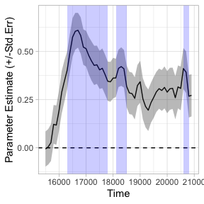

```r
plot(tb_analysis_bonf) + theme_light()
```

```r
summary(tb_analysis_bonf)
```

```
## Test Type:    t.test
## Predictor:    Target
## Formula:  Prop ~ Target
## Runs of Significant Time Bins:
## Positive Run 1  =====
##  Time:        16300 - 17800
## Positive Run 2  =====
##  Time:        18100 - 18500
## Positive Run 3  =====
##  Time:        20600 - 20800
```

This method seems overly conservative, and indeed it is: this correction assumes the ‘worst case scenario’ that all time-bins are fully independent– which as we mentioned, is clearly not the case. Other methods are less stringent. Any method available in R’s `p.adjust` function are available to `analyze_time_bins`. See the documentation of that function for more details. As mentioned there, there isn’t really a good reason to use the Bonferroni method, because Holm’s method controls family-wise error just as well, but sometimes is more powerful:

```r
tb_analysis_holm <- analyze_time_bins(data = response_time, predictor_column = "Target", test = "t.test", alpha = .05,
                                 p_adjust_method = "holm")
```

```
## Computing t.test for each time bin...
```

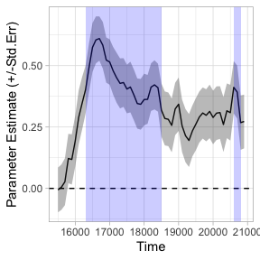

```r
plot(tb_analysis_holm) + theme_light()
```

```r
summary(tb_analysis_holm)
```

```
## Test Type:    t.test
## Predictor:    Target
## Formula:  Prop ~ Target
## Runs of Significant Time Bins:
## Positive Run 1  =====
##  Time:        16300 - 18500
## Positive Run 2  =====
##  Time:        20600 - 20800
```

## Bootstrapped smoothed divergence analysis

One concern with multiple-testing using corrections is that it severely limits our power: by controlling the family-wise error rate, we sacrifice our ability to detect effects when they are present.

In fact, even the uncorrected, overly liberal test seems to have made a small error in the conservative direction: it split our runs of statistically significant time-bins in two, due to a small downward blip in one of the time-bins. It seems unlikely the effect actually vanished for this single time bin: instead, it seems more likely that eye-tracking data is noisy, and that we should try to ignore the small variations that are a result of this noise.

One approach is to perform a statistical test that operates over a smoothed version of our data (similar to Wendt et al., 2014). This involves:

1. Resampling with replacement from our data (e.g., randomly resampling subjects from each condition).
2. For each resample, fitting a smoothing curve to the data (choosing either `smooth.spline()`, `loess()`, or no smoother)
3. Repeating steps (1) and (2) thousands of times to generate a distribution,
4. Obtain the 95% confidence intervals of this distribution. Those time-bins whose confidence intervals do not overlap with zero can be considered statistically significant at alpha = .05.

This is a useful technique for estimating the timepoints of divergence between two conditions, while the smoothing helps remove minor deviations that might disrupt what would otherwise be considered a single divergent period. This can be especially helpful in infant data, which can be extremely noisy. Note that this approach can only deal with testing differences across two levels of a predictor (e.g., an experimental manipulation, not a continous covariate).

This method returns a list of divergences between your two conditions based on time windows in which (by default) the 95% confidence intervals did not include 0 (i.e., *p* < .05).

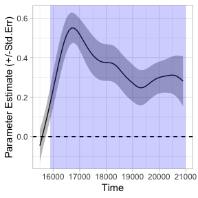

```r
tb_bootstrap <- analyze_time_bins(response_time, predictor_column = 'Target', test= 'boot_splines',
                                  within_subj = TRUE, bs_samples = 1000, alpha = .05)
plot(tb_bootstrap) + theme_light()
```

```r
summary(tb_bootstrap)
```

```
## Test Type:    boot_splines
## Predictor:    Target
## Formula:  Prop ~ Target
## Runs of Significant Time Bins:
## Positive Run 1  =====
##  Time:        15900 - 21000
```

We can see that this method (probably correctly) identified that our trial involves a single divergence in looking across conditions, rather than two divergences separated by a single time-bin.

However, it is important to note that this method doesn’t explicitly control the family-wise error rate. And unfortunately, because this test doesn’t produce a p-value for each bin, we can only perform a (manual) Bonferroni-correction.

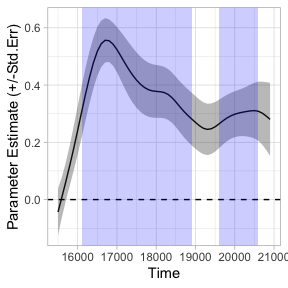

```r
tb_bootstrap_bonf <- analyze_time_bins(response_time, predictor_column = 'Target', test= 'boot_splines',
                                  within_subj = TRUE, alpha = .05/num_time_bins)
plot(tb_bootstrap_bonf) + theme_light()
```

```r
summary(tb_bootstrap_bonf)
```

```
## Test Type:    boot_splines
## Predictor:    Target
## Formula:  Prop ~ Target
## Runs of Significant Time Bins:
## Positive Run 1  =====
##  Time:        16100 - 18900
## Positive Run 2  =====
##  Time:        19600 - 20600
```

Once correcting, the test suffers from many of the same problems as the Bonferroni t-tests.

## Bootstrapped cluster-based permutation analysis

Above we saw problems both with false-alarms and sensitivity. This is not a zero-sum game. One approach that offers an excellent compromise between the two is referred to as a cluster-based permutation analysis (Maris & Oostenveld, 2007).

This procedure involves two main steps. First, we run a test on each time bin that quantifies the statistical significance of the effect at each time bin. This acts as a “first pass,” and we group together into clusters all adjacent bins that get through this first pass. We then shuffle the data, performing this test-then-cluster on each iteration of the shuffled data. This shuffled data tells us what kinds of clusters we should expect if there were no effect (i.e., randomly scrambled data).

In more detail, what eyetrackingR does is:

1. Run a statistical test on each time-bin of your data. This can be any valid and appropriate statistic that quantifies the probability of the data under the null hypothesis: t-test, wilcox.test, linear models, etc.– whatever is appropriate for your data.
2. Take the time-bins whose test passed the threshold statistic (e.g., t > 2), and group them by adjacency. We will call these time-clusters.
3. For each time-cluster, calculate the sum of the statistics for the time-bins inside it.
4. Take the data and randomly shuffle it.
5. Perform (1)-(3) on the shuffled dataset. Save the biggest sum-statistic.
6. Repeat steps (4) and (5) hundreds of times. This will lead to a distribution of summed-statistics, each representing the results of a statistical test on shuffled data. Intuitively, this distribution represents what kind of sum-statistics we would expect to get by chance, if no effect were present (i.e., if the data were just randomly shuffled).
7. Compare the cluster-statistics from step (3) to the distribution found in (6) to obtain a p-value. So, for example, if we get a distribution of sum-statistics, and 6.4% of the sum-statistics in this distribution are more extreme the sum-statistic of our cluster, then our *p*-value for this cluster is *p* = .064.

This analysis has two main advantages over the ones reviewed so far:

1. It naturally controls the false-alarm rate while sacrificing little sensitivity.
2. The implementation in eyetrackingR allows you to use this method with a variety of statistical techniques (`t.test`, `wilcox.test`, `(g)lm`, and `(g)lmer`), so that continuous predictors, covariates, etc. can also be included in the model being tested. We even provide (experimental) support for using boot-splines as the test performed at each time bin.

To perform this analysis, we first need to set a threshold for our “first pass,” for which time-bins will be included in clusters. This can be a source of misconceptions. The *size* of the initial threshold you set should be set in a principled way (e.g., don’t run the cluster analysis, examine the result, then decide you want to use a different threshold). But perhaps surprisingly, the test controls the family-wise error rate, even if we don’t choose a threshold that corresponds to p = .05. This is because the threshold affects both the first pass and the shuffled data: if we let more time-bins into our intial clusters, then more time-bins will be let into our shuffled data as well, and bigger time-clusters will be expected under the null distribution.

Here, we’ll just set our threshold based on the t-distribution: ~2.06 corresponds to the usual statistic we would use in a t-test for this sample.

```r
num_sub = length(unique((response_window_clean$ParticipantName)))
threshold_t = qt(p = 1 - .05/2,
                 df = num_sub-1) # pick threshold t based on alpha = .05 two tailed
```

We can then look for initial clusters:

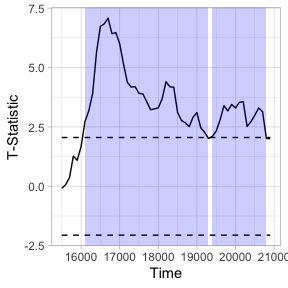

```r
df_timeclust <- make_time_cluster_data(response_time,
                                      test= "t.test", paired=T,
                                      predictor_column = "Target",
                                      threshold = threshold_t)
plot(df_timeclust) +  ylab("T-Statistic") + theme_light()
```

```r
summary(df_timeclust)
```

```
## Test Type:    t.test
## Predictor:    Target
## Formula:  Pair(Prop[Target == "Animate"], Prop[Target == "Inanimate"]) ~      1
## Summary of Clusters ======
##   Cluster Direction SumStatistic StartTime EndTime
## 1       1  Positive    132.29900     16100   19300
## 2       2  Positive     42.31067     19400   20800
```

The above tells us there are two potential clusters. As described in the procedure above, eyetrackingR next bootstraps a “null” distribution, which can be visualized:

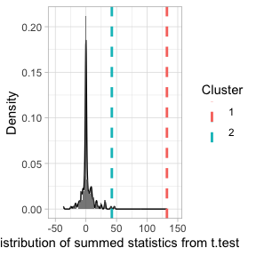

```r
clust_analysis <- analyze_time_clusters(df_timeclust, within_subj=TRUE, paired=TRUE,quiet = TRUE,
                                        samples=150) # in practice, you should use a lot more - around 1000
plot(clust_analysis) + theme_light()
```

How can we interpret these results?

```r
summary(clust_analysis)
```

```
## Test Type:    t.test
## Predictor:    Target
## Formula:  Pair(Prop[Target == "Animate"], Prop[Target == "Inanimate"]) ~      1
## Null Distribution   ======
##  Mean:        1.6225
##  2.5%:        -17.0175
## 97.5%:        30.9954
## Summary of Clusters ======
##   Cluster Direction SumStatistic StartTime EndTime Probability
## 1       1  Positive    132.29900     16100   19300 0.000000000
## 2       2  Positive     42.31067     19400   20800 0.006666667
```

The probabilities listed above tell us the probability of seeing the effect of each cluster (or bigger) if the null-hypothesis were true. Of course, these probabilities aren’t accurate unless we run enough iterations to get a fuller simulation of the whole null distribution (we’ve just ommitted this for purposes of speed).

Note that we actually ended up getting virtually identical results to our initial analysis of sequential time-bins! That’s because the effect here was quite large; we didn’t have to worry about spuriously significant time-bins because there probably weren’t any.

Let’s run a quick analysis that does a better job of showing off the virtues of cluster analysis. We’ll examine the hypothesis that infants with higher MCDI vocabulary scores have a baseline bias to look at the animate object. Note that this is different from the hypothesis that high-vocab infants are likely to look at the trial *target*; we are instead examining the unlikely hypothesis that high-vocab infants have a baseline preference.

This analysis is good for showing off the virtues of cluster analysis for two reasons. First, the effect is unlikely to be real, but (we will see that) sequential independent tests at each time-bin give some false-alarms. Second, this effect can’t be assessed with analyses that only allow for testing two-level factors (like t-tests), because our predictor is continuous. EyetrackingR allows us to accomplish this quite easily by using `lm` as our test instead of `t-test`.

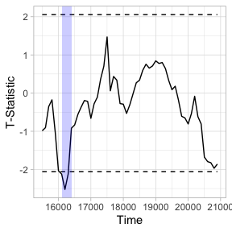

```r
response_time_between <- make_time_sequence_data(response_window_clean,
                                  time_bin_size = 100,
                                  predictor_columns = c("Sex", "MCDI_Total"),
                                  aois = "Animate",
                                  summarize_by = "ParticipantName" )

df_timeclust_between <- make_time_cluster_data(response_time_between,
                                      test= "lm",
                                      predictor_column = "MCDI_Total",
                                      threshold = threshold_t)
plot(df_timeclust_between) +  ylab("T-Statistic") + theme_light()
```

```r
summary(df_timeclust_between)
```

```
## Test Type:    lm
## Predictor:    MCDI_Total
## Formula:  Prop ~ MCDI_Total
## Summary of Clusters ======
##   Cluster Direction SumStatistic StartTime EndTime
## 1       1  Negative    -6.766357     16100   16400
```

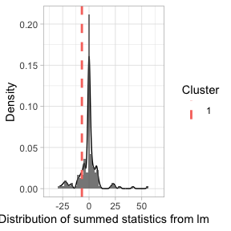

```r
set.seed(5)
clust_analysis_between <- analyze_time_clusters(df_timeclust_between, within_subj = FALSE, quiet = TRUE,
                                        samples=150) # in practice, you should use a lot more
plot(clust_analysis_between) + theme_light()
```

```r
summary(clust_analysis_between)
```

```
## Test Type:    lm
## Predictor:    MCDI_Total
## Formula:  Prop ~ MCDI_Total
## Null Distribution   ======
##  Mean:        -0.2957
##  2.5%:        -23.0358
## 97.5%:        23.4564
## Summary of Clusters ======
##   Cluster Direction SumStatistic StartTime EndTime Probability
## 1       1  Negative    -6.766357     16100   16400   0.2933333
```

## References

Maris, E., Oostenveld, R., (2007). Nonparametric statistical testing of EEG- and MEG-data. Journal of Neuroscience Methods 164 (1), 177–190.

Wendt, D., Brand, T., & Kollmeier, B. (2014). An Eye-Tracking Paradigm for Analyzing the Processing Time of Sentences with Different Linguistic Complexities. PLoS ONE, 9(6), e100186. https://doi.org/10.1371/journal.pone.0100186.t003